# Ames Housing Prices: Part I - EDA & Imputing Missing Data

Sanjeev Gadre

June 28, 2019

Loading the required libraries.

Loading required functions.

### Getting the Data

1. We add a column `SalePrice` to the *test* dataset and assign a default value of “1000”.
2. We combide *train* and *test* datasets, for easier changes to the dataframe structure, imputing missing values and analysis.
3. We start by getting a sense of the *train* dataset and its structure.

```
## [1] "Sample examples from the train dataset"
```

```
##   Id MSSubClass MSZoning LotFrontage LotArea Street Alley LotShape
## 1  1         60       RL          65    8450   Pave  <NA>      Reg
## 2  2         20       RL          80    9600   Pave  <NA>      Reg
## 3  3         60       RL          68   11250   Pave  <NA>      IR1
## 4  4         70       RL          60    9550   Pave  <NA>      IR1
## 5  5         60       RL          84   14260   Pave  <NA>      IR1
## 6  6         50       RL          85   14115   Pave  <NA>      IR1
##   LandContour Utilities LotConfig LandSlope Neighborhood Condition1
## 1         Lvl    AllPub    Inside       Gtl      CollgCr       Norm
## 2         Lvl    AllPub       FR2       Gtl      Veenker      Feedr
## 3         Lvl    AllPub    Inside       Gtl      CollgCr       Norm
## 4         Lvl    AllPub    Corner       Gtl      Crawfor       Norm
## 5         Lvl    AllPub       FR2       Gtl      NoRidge       Norm
## 6         Lvl    AllPub    Inside       Gtl      Mitchel       Norm
##   Condition2 BldgType HouseStyle OverallQual OverallCond YearBuilt
```

[output cut: 76 more lines]

```
## [1] "Structure of the train dataset"
```

```
## 'data.frame':    1460 obs. of  81 variables:
##  $ Id           : int  1 2 3 4 5 6 7 8 9 10 ...
##  $ MSSubClass   : int  60 20 60 70 60 50 20 60 50 190 ...
##  $ MSZoning     : Factor w/ 5 levels "C (all)","FV",..: 4 4 4 4 4 4 4 4 5 4 ...
##  $ LotFrontage  : int  65 80 68 60 84 85 75 NA 51 50 ...
##  $ LotArea      : int  8450 9600 11250 9550 14260 14115 10084 10382 6120 7420 ...
##  $ Street       : Factor w/ 2 levels "Grvl","Pave": 2 2 2 2 2 2 2 2 2 2 ...
##  $ Alley        : Factor w/ 2 levels "Grvl","Pave": NA NA NA NA NA NA NA NA NA NA ...
##  $ LotShape     : Factor w/ 4 levels "IR1","IR2","IR3",..: 4 4 1 1 1 1 4 1 4 4 ...
##  $ LandContour  : Factor w/ 4 levels "Bnk","HLS","Low",..: 4 4 4 4 4 4 4 4 4 4 ...
##  $ Utilities    : Factor w/ 2 levels "AllPub","NoSeWa": 1 1 1 1 1 1 1 1 1 1 ...
##  $ LotConfig    : Factor w/ 5 levels "Corner","CulDSac",..: 5 3 5 1 3 5 5 1 5 1 ...
##  $ LandSlope    : Factor w/ 3 levels "Gtl","Mod","Sev": 1 1 1 1 1 1 1 1 1 1 ...
##  $ Neighborhood : Factor w/ 25 levels "Blmngtn","Blueste",..: 6 25 6 7 14 12 21 17 18 4 ...
##  $ Condition1   : Factor w/ 9 levels "Artery","Feedr",..: 3 2 3 3 3 3 3 5 1 1 ...
```

[output cut: 67 more lines]

### Pre-Process - I

1. We change the data type for a few features to better align it with the type of feature data. Specifically, we convert `MSSubClass`, `OverallQual`, `OverallCond` from `<int>` to `<fctr>`.
2. We identify the features in the *train* dataset that report `NA` values

```
## [1] "Features in train dataset reporting NA values"
```

```
##  LotFrontage        Alley   MasVnrType   MasVnrArea     BsmtQual
##          259         1369            8            8           37
##     BsmtCond BsmtExposure BsmtFinType1 BsmtFinType2   Electrical
##           37           38           37           38            1
##  FireplaceQu   GarageType  GarageYrBlt GarageFinish   GarageQual
##          690           81           81           81           81
##   GarageCond       PoolQC        Fence  MiscFeature
##           81         1453         1179         1406
```

**Observations**

Some features are *incorrectly* coded in that `NA` doesn’t mean missing data but has a an alternate meaning. We convert `NA` to a more appropriate values for the following features:

1. When a house has *No Alley Access*, it is recorded under the column `Alley` as `NA` which is corrected to `NoAccess`.
2. When a house has *No Basement*, it is recorded under the columns `BsmtQual`, `BsmtCond`, `BsmtExposure`, `BsmtFinType1`, `BsmtFinType2` as `NA` which is corrected to `NoBsmt`.
3. When a house has *No Fireplace*, it is recorded under the column `FireplaceQu` as `NA` which is corrected to `NoFpl`.
4. When a house has *No Garage*, it is recorded under the columns `GarageType`, `GarageFinish`, `GarageQual`, `GarageCond` as `NA` which is corrected to `NoGrg`.
5. When a house has *No Pool*, it is recorded under the column `PoolQc` as `NA` which is corrected to `NoPool`.
6. When a house has *No Fence*, it is recorded under the column `Fence` as `NA` which is corrected to `NoFence`.
7. When a house has *No Miscellaneous Features*, it is recorded under the column `MiscFeature` as `NA` which is corrected to `NoMisc`.

We apply these changes to both *train* and *test* datasets.

8. We identify the features in the *train* dataset that are reporting `NA`.

```
## [1] "Features in train dataset reporting NA values"
```

```
## LotFrontage  MasVnrType  MasVnrArea  Electrical GarageYrBlt
##         259           8           8           1          81
```

### Exploratory Data Analysis - I

We get additional visibility to the features in the *train* dataset reporting `NA` values

```
## Property Ids reporting NA for GarageYrBlt
```

```
##        Id GarageType GarageYrBlt
## 40     40      NoGrg          NA
## 49     49      NoGrg          NA
## 79     79      NoGrg          NA
## 89     89      NoGrg          NA
## 90     90      NoGrg          NA
## 100   100      NoGrg          NA
## 109   109      NoGrg          NA
## 126   126      NoGrg          NA
## 128   128      NoGrg          NA
## 141   141      NoGrg          NA
## 149   149      NoGrg          NA
## 156   156      NoGrg          NA
## 164   164      NoGrg          NA
## 166   166      NoGrg          NA
```

[output cut: 67 more lines]

```
## Distribution of types of 'Elec. System' used
```

```
## Elec. System Used
##  FuseA  FuseF  FuseP    Mix  SBrkr
## 0.0644 0.0185 0.0021 0.0007 0.9143
```

```
## Distribution of types of 'Masonry Veneer' used
```

```
## Masonry Veneer Type
##  BrkCmn BrkFace    None   Stone
##  0.0103  0.3065  0.5950  0.0882
```

```
## Distribution of 'Masonry Veneer Area'
```

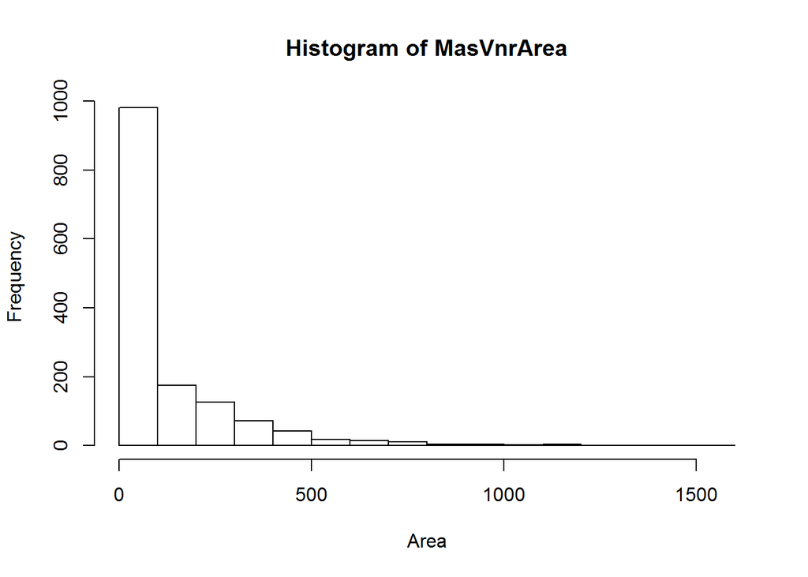

[output not shown]

[figure not shown]

**Observations:**

### Pre-Process - II

We use the insights above to impute missing values to both the *train* and *test* datasets for the 5 features analysed above

1. We make an experience-based assumption that a property’s value is dependent on the presence or absence of a garage rather that the age of the garage. As such, we *drop* the feature `GarageYrBlt` as the information of the presence or absence of a garage is already captured in `GarageType`.
2. To the `NA` in `Electrical` and `MasVnrType` we impute the mode value of the respective feature based on the remaining train examples.
3. To the `NA` in `MasVnrArea` and `LotFrontage` we impute the median value of the respective feature based on the remaining train examples.
4. We verify that there indeed are no more missing values in the *train* dataset.
5. Finally we identify the missing values in the *test* dataset.

It is important to note that we **only** use the *train* examples to decide on the median and mode values to impute.

```
## [1] "Features in train dataset reporting NA values"
```

```
## named integer(0)
```

```
## [1] "Features in test dataset reporting NA values"
```

```
##     MSZoning    Utilities  Exterior1st  Exterior2nd   BsmtFinSF1
##            4            2            1            1            1
##   BsmtFinSF2    BsmtUnfSF  TotalBsmtSF BsmtFullBath BsmtHalfBath
##            1            1            1            2            2
##  KitchenQual   Functional   GarageCars   GarageArea     SaleType
##            1            2            1            1            1
```

### Exploratory Data Analysis - II

1. We get some additional visibility to the examples in the *test* dataset reporting `NA`; specifically we ascertain if there are examples reporting `NA` under multiple features.

```
##        Id Neighborhood MSZoning
## 1916 1916       IDOTRR     <NA>
## 2217 2217       IDOTRR     <NA>
## 2251 2251       IDOTRR     <NA>
## 2905 2905      Mitchel     <NA>
```

```
##        Id Neighborhood Utilities
## 1916 1916       IDOTRR      <NA>
## 1946 1946      Gilbert      <NA>
```

```
##        Id MSSubClass Exterior1st Exterior2nd
## 2152 2152         30        <NA>        <NA>
```

```
##        Id MSSubClass BsmtQual BsmtFinSF1 BsmtFinSF2 BsmtUnfSF TotalBsmtSF
## 2121 2121         20   NoBsmt         NA         NA        NA          NA
```

```
##        Id MSSubClass BsmtQual BsmtFullBath BsmtHalfBath
## 2121 2121         20   NoBsmt           NA           NA
## 2189 2189         20   NoBsmt           NA           NA
```

```
##        Id MSSubClass KitchenQual
## 1556 1556         50        <NA>
```

```
##        Id MSSubClass Functional
## 2217 2217         20       <NA>
## 2474 2474         50       <NA>
```

```
##        Id GarageType GarageCars GarageArea
## 2577 2577     Detchd         NA         NA
```

```
##        Id MSSubClass SaleType
## 2490 2490         20     <NA>
```

**Observations**

1. A single exampe 2152 reports `NA` for both `Exterior1st` and `Exterior2nd`.
2. Example ids. 2121 and 2189 both report absence of a basement and hence we can impute `0` to all related features like `BsmtFinSF1`, `BsmtFinSF2`, `BsmtUnfSF`, `TotalBsmtSF`, `BsmtFullBath` and `BsmtHalfBath`.
3. A single example 2577 reports `NA` for both `GarageCars` and `GarageArea`.

**Insights**

1. We make experience based hypotheses that features:
   1. `MSZoning` and `Utilities` depend on the `Neighborhood`,
   2. `Exterior1st`, `Exterior2nd`, `KitchenQual`, `Functional` and `SaleType` depend on the type of house (`MSSubClass`), and
   3. `GarageCars` and `GarageArea` depend on typle of Garage (`GarageType`).
2. To validate this assumption, we look at the distribution of:
   1. `MSZoning` and `Utilities` for different `Neighborhood`
   2. `Exterior1st`, `Exterior2nd`, `KitchenQual`, `Functional` and `SaleType` for different `MSSubclass`, and
   3. `GarageCars` and `GarageArea` for different `GarageType`.

We look at these distributions only for the *train* examples.

```
## The first table of each pair of tables below show the overall distribution of a feature across all examples and the second one the distribution of the feature stratified by 'MSSubClass'
```

```
## MSZoning
## C (all)      FV      RH      RL      RM
##  0.0068  0.0445  0.0110  0.7884  0.1493
```

```
##          Neighborhood
## MSZoning  Blmngtn Blueste BrDale BrkSide ClearCr CollgCr Crawfor Edwards
##   C (all)  0.0000  0.0000 0.0000  0.0000  0.0000  0.0000  0.0000  0.0000
##   FV       0.0000  0.0000 0.0000  0.0000  0.0000  0.0000  0.0000  0.0000
##   RH       0.0000  0.0000 0.0000  0.0000  0.0000  0.0000  0.0392  0.0200
##   RL       0.9412  0.0000 0.0000  0.4828  1.0000  0.9333  0.9020  0.9000
##   RM       0.0588  1.0000 1.0000  0.5172  0.0000  0.0667  0.0588  0.0800
##          Neighborhood
## MSZoning  Gilbert IDOTRR MeadowV Mitchel  NAmes NoRidge NPkVill NridgHt
##   C (all)  0.0000 0.2432  0.0000  0.0000 0.0000  0.0000  0.0000  0.0000
##   FV       0.0000 0.0000  0.0000  0.0000 0.0000  0.0000  0.0000  0.0000
##   RH       0.0000 0.0000  0.0000  0.0000 0.0089  0.0000  0.0000  0.0000
##   RL       1.0000 0.0000  0.0000  0.8980 0.9911  1.0000  1.0000  0.9870
##   RM       0.0000 0.7568  1.0000  0.1020 0.0000  0.0000  0.0000  0.0130
##          Neighborhood
## MSZoning  NWAmes OldTown Sawyer SawyerW Somerst StoneBr  SWISU Timber
##   C (all) 0.0000  0.0088 0.0000  0.0000  0.0000  0.0000 0.0000 0.0000
##   FV      0.0000  0.0000 0.0000  0.0000  0.7558  0.0000 0.0000 0.0000
##   RH      0.0000  0.0000 0.0000  0.0847  0.0000  0.0000 0.2000 0.0000
##   RL      1.0000  0.1504 0.9730  0.9153  0.2442  1.0000 0.8000 1.0000
##   RM      0.0000  0.8407 0.0270  0.0000  0.0000  0.0000 0.0000 0.0000
##          Neighborhood
## MSZoning  Veenker
##   C (all)  0.0000
##   FV       0.0000
##   RH       0.0000
##   RL       1.0000
##   RM       0.0000
```

```
## Utilities
## AllPub NoSeWa
## 0.9993 0.0007
```

```
##          Neighborhood
## Utilities Blmngtn Blueste BrDale BrkSide ClearCr CollgCr Crawfor Edwards
##    AllPub  1.0000  1.0000 1.0000  1.0000  1.0000  1.0000  1.0000  1.0000
##    NoSeWa  0.0000  0.0000 0.0000  0.0000  0.0000  0.0000  0.0000  0.0000
##          Neighborhood
## Utilities Gilbert IDOTRR MeadowV Mitchel  NAmes NoRidge NPkVill NridgHt
##    AllPub  1.0000 1.0000  1.0000  1.0000 1.0000  1.0000  1.0000  1.0000
##    NoSeWa  0.0000 0.0000  0.0000  0.0000 0.0000  0.0000  0.0000  0.0000
##          Neighborhood
## Utilities NWAmes OldTown Sawyer SawyerW Somerst StoneBr  SWISU Timber
##    AllPub 1.0000  1.0000 1.0000  1.0000  1.0000  1.0000 1.0000 0.9737
##    NoSeWa 0.0000  0.0000 0.0000  0.0000  0.0000  0.0000 0.0000 0.0263
##          Neighborhood
## Utilities Veenker
##    AllPub  1.0000
##    NoSeWa  0.0000
```

```
## Exterior1st
## AsbShng AsphShn BrkComm BrkFace  CBlock CemntBd HdBoard ImStucc MetalSd
##  0.0137  0.0007  0.0014  0.0342  0.0007  0.0418  0.1521  0.0007  0.1507
## Plywood   Stone  Stucco VinylSd Wd Sdng WdShing
##  0.0740  0.0014  0.0171  0.3527  0.1411  0.0178
```

```
##          MSSubclass
## Xterior1      20     30     40     45     50     60     70     75     80
##   AsbShng 0.0037 0.0290 0.0000 0.0000 0.0486 0.0000 0.0333 0.1250 0.0345
##   AsphShn 0.0000 0.0000 0.0000 0.0000 0.0000 0.0000 0.0000 0.0000 0.0000
##   BrkComm 0.0037 0.0000 0.0000 0.0000 0.0000 0.0000 0.0000 0.0000 0.0000
##   BrkFace 0.0541 0.0145 0.0000 0.0000 0.0556 0.0000 0.0667 0.0000 0.0345
##   CBlock  0.0000 0.0000 0.0000 0.0000 0.0069 0.0000 0.0000 0.0000 0.0000
##   CemntBd 0.0317 0.0000 0.0000 0.0000 0.0139 0.0435 0.0167 0.0625 0.0000
##   HdBoard 0.1903 0.0000 0.2500 0.0000 0.0278 0.1839 0.0167 0.0000 0.3103
##   ImStucc 0.0019 0.0000 0.0000 0.0000 0.0000 0.0000 0.0000 0.0000 0.0000
##   MetalSd 0.1175 0.2754 0.2500 0.5000 0.2847 0.0368 0.2167 0.1875 0.1207
##   Plywood 0.0784 0.0000 0.2500 0.0000 0.0069 0.0569 0.0000 0.0000 0.2069
##   Stone   0.0037 0.0000 0.0000 0.0000 0.0000 0.0000 0.0000 0.0000 0.0000
##   Stucco  0.0019 0.1014 0.0000 0.0000 0.0347 0.0033 0.1333 0.0625 0.0000
##   VinylSd 0.3769 0.1304 0.2500 0.0000 0.1528 0.6388 0.0833 0.0000 0.2069
##   Wd Sdng 0.1231 0.3913 0.0000 0.4167 0.3194 0.0234 0.4333 0.5625 0.0862
##   WdShing 0.0131 0.0580 0.0000 0.0833 0.0486 0.0134 0.0000 0.0000 0.0000
##          MSSubclass
## Xterior1      85     90    120 150    160    180    190
##   AsbShng 0.0000 0.0385 0.0000     0.0000 0.0000 0.0333
##   AsphShn 0.0000 0.0192 0.0000     0.0000 0.0000 0.0000
##   BrkComm 0.0000 0.0000 0.0000     0.0000 0.0000 0.0000
##   BrkFace 0.0000 0.0577 0.0345     0.0000 0.0000 0.0000
##   CBlock  0.0000 0.0000 0.0000     0.0000 0.0000 0.0000
##   CemntBd 0.0500 0.0000 0.1034     0.1587 0.7000 0.0000
##   HdBoard 0.4000 0.1538 0.0690     0.2540 0.0000 0.1000
##   ImStucc 0.0000 0.0000 0.0000     0.0000 0.0000 0.0000
##   MetalSd 0.1000 0.2115 0.1379     0.3333 0.0000 0.3333
##   Plywood 0.1500 0.2692 0.1149     0.0952 0.0000 0.0667
##   Stone   0.0000 0.0000 0.0000     0.0000 0.0000 0.0000
##   Stucco  0.0000 0.0385 0.0000     0.0000 0.0000 0.0000
##   VinylSd 0.2000 0.1346 0.5057     0.1587 0.3000 0.1667
##   Wd Sdng 0.0500 0.0577 0.0230     0.0000 0.0000 0.3000
##   WdShing 0.0500 0.0192 0.0115     0.0000 0.0000 0.0000
```

```
## Exterior2nd
## AsbShng AsphShn Brk Cmn BrkFace  CBlock CmentBd HdBoard ImStucc MetalSd
##  0.0137  0.0021  0.0048  0.0171  0.0007  0.0411  0.1418  0.0068  0.1466
##   Other Plywood   Stone  Stucco VinylSd Wd Sdng Wd Shng
##  0.0007  0.0973  0.0034  0.0178  0.3452  0.1349  0.0260
```

```
##          MSSubclass
## Xterior2      20     30     40     45     50     60     70     75     80
##   AsbShng 0.0056 0.0290 0.0000 0.0000 0.0486 0.0000 0.0167 0.1250 0.0345
##   AsphShn 0.0000 0.0000 0.0000 0.0000 0.0000 0.0033 0.0000 0.0000 0.0172
##   Brk Cmn 0.0037 0.0000 0.0000 0.0000 0.0000 0.0000 0.0000 0.0000 0.0000
##   BrkFace 0.0280 0.0145 0.0000 0.0000 0.0069 0.0000 0.0333 0.0000 0.0172
##   CBlock  0.0000 0.0000 0.0000 0.0000 0.0069 0.0000 0.0000 0.0000 0.0000
##   CmentBd 0.0317 0.0000 0.0000 0.0000 0.0139 0.0401 0.0167 0.0625 0.0000
##   HdBoard 0.1623 0.0000 0.2500 0.0000 0.0417 0.1706 0.0167 0.0000 0.3621
##   ImStucc 0.0075 0.0000 0.0000 0.0000 0.0000 0.0067 0.0000 0.0000 0.0172
##   MetalSd 0.1175 0.2464 0.2500 0.5000 0.2847 0.0368 0.2000 0.1875 0.0862
##   Other   0.0019 0.0000 0.0000 0.0000 0.0000 0.0000 0.0000 0.0000 0.0000
##   Plywood 0.1343 0.0145 0.2500 0.0000 0.0278 0.0736 0.0167 0.0625 0.1724
##   Stone   0.0037 0.0000 0.0000 0.0000 0.0069 0.0000 0.0000 0.0000 0.0000
##   Stucco  0.0000 0.1159 0.0000 0.0000 0.0417 0.0033 0.1500 0.0625 0.0000
##   VinylSd 0.3675 0.1304 0.2500 0.0000 0.1458 0.6388 0.1000 0.0000 0.2069
##   Wd Sdng 0.1231 0.3768 0.0000 0.5000 0.3194 0.0167 0.3667 0.3750 0.0862
##   Wd Shng 0.0131 0.0725 0.0000 0.0000 0.0556 0.0100 0.0833 0.1250 0.0000
##          MSSubclass
## Xterior2      85     90    120 150    160    180    190
##   AsbShng 0.0000 0.0192 0.0000     0.0000 0.0000 0.0667
##   AsphShn 0.0000 0.0192 0.0000     0.0000 0.0000 0.0000
##   Brk Cmn 0.0000 0.0000 0.0000     0.0794 0.0000 0.0000
##   BrkFace 0.0000 0.0385 0.0345     0.0000 0.0000 0.0000
##   CBlock  0.0000 0.0000 0.0000     0.0000 0.0000 0.0000
##   CmentBd 0.0500 0.0000 0.1034     0.1587 0.7000 0.0000
##   HdBoard 0.4000 0.1346 0.0690     0.2381 0.0000 0.1333
##   ImStucc 0.0000 0.0192 0.0115     0.0159 0.0000 0.0000
##   MetalSd 0.1000 0.1923 0.1379     0.3333 0.0000 0.3333
##   Other   0.0000 0.0000 0.0000     0.0000 0.0000 0.0000
##   Plywood 0.1500 0.3077 0.1034     0.0159 0.0000 0.0333
##   Stone   0.0000 0.0385 0.0000     0.0000 0.0000 0.0000
##   Stucco  0.0000 0.0192 0.0000     0.0000 0.0000 0.0000
##   VinylSd 0.2000 0.1346 0.4943     0.1111 0.3000 0.1000
##   Wd Sdng 0.0500 0.0577 0.0230     0.0000 0.0000 0.3000
##   Wd Shng 0.0500 0.0192 0.0230     0.0476 0.0000 0.0333
```

```
## KitchenQual
##     Ex     Fa     Gd     TA
## 0.0685 0.0267 0.4014 0.5034
```

```
##            MSSubclass
## KitchenQual     20     30     40     45     50     60     70     75     80
##          Ex 0.0802 0.0145 0.0000 0.0000 0.0139 0.1137 0.0500 0.0625 0.0345
##          Fa 0.0112 0.2029 0.0000 0.0000 0.0417 0.0033 0.0667 0.0625 0.0000
##          Gd 0.3899 0.1159 0.5000 0.3333 0.2083 0.6321 0.3333 0.3125 0.2931
##          TA 0.5187 0.6667 0.5000 0.6667 0.7361 0.2508 0.5500 0.5625 0.6724
##            MSSubclass
## KitchenQual     85     90    120 150    160    180    190
##          Ex 0.0500 0.0000 0.1379     0.0000 0.1000 0.0000
##          Fa 0.0000 0.0385 0.0000     0.0000 0.0000 0.1667
##          Gd 0.3500 0.0192 0.7011     0.4762 0.1000 0.0667
##          TA 0.6000 0.9423 0.1609     0.5238 0.8000 0.7667
```

```
## Functional
##   Maj1   Maj2   Min1   Min2    Mod    Sev    Typ
## 0.0096 0.0034 0.0212 0.0233 0.0103 0.0007 0.9315
```

```
##           MSSubclass
## Functional     20     30     40     45     50     60     70     75     80
##       Maj1 0.0056 0.0435 0.0000 0.0000 0.0069 0.0000 0.0167 0.0000 0.0172
##       Maj2 0.0019 0.0435 0.0000 0.0000 0.0069 0.0000 0.0000 0.0000 0.0000
##       Min1 0.0317 0.0290 0.0000 0.0000 0.0347 0.0033 0.0167 0.0000 0.0345
##       Min2 0.0168 0.0145 0.0000 0.0000 0.0833 0.0100 0.0500 0.0000 0.0517
##       Mod  0.0112 0.0145 0.0000 0.0000 0.0278 0.0033 0.0000 0.0000 0.0000
##       Sev  0.0000 0.0000 0.0000 0.0000 0.0000 0.0033 0.0000 0.0000 0.0000
##       Typ  0.9328 0.8551 1.0000 1.0000 0.8403 0.9799 0.9167 1.0000 0.8966
##           MSSubclass
## Functional     85     90    120 150    160    180    190
##       Maj1 0.0000 0.0000 0.0000     0.0794 0.0000 0.0000
##       Maj2 0.0000 0.0000 0.0000     0.0000 0.0000 0.0000
##       Min1 0.0000 0.0000 0.0000     0.0476 0.0000 0.0000
##       Min2 0.1000 0.0000 0.0000     0.0000 0.0000 0.0333
##       Mod  0.0000 0.0192 0.0000     0.0000 0.0000 0.0667
##       Sev  0.0000 0.0000 0.0000     0.0000 0.0000 0.0000
##       Typ  0.9000 0.9808 1.0000     0.8730 1.0000 0.9000
```

```
## SaleType
##    COD    Con  ConLD  ConLI  ConLw    CWD    New    Oth     WD
## 0.0295 0.0014 0.0062 0.0034 0.0034 0.0027 0.0836 0.0021 0.8678
```

```
##         MSSubclass
## SaleType     20     30     40     45     50     60     70     75     80
##    COD   0.0466 0.0290 0.0000 0.0000 0.0278 0.0000 0.0333 0.0000 0.0172
##    Con   0.0000 0.0000 0.0000 0.0000 0.0000 0.0033 0.0000 0.0000 0.0000
##    ConLD 0.0019 0.0145 0.0000 0.0000 0.0139 0.0000 0.0000 0.0000 0.0000
##    ConLI 0.0019 0.0000 0.0000 0.0000 0.0069 0.0067 0.0000 0.0000 0.0000
##    ConLw 0.0000 0.0145 0.0000 0.0000 0.0069 0.0033 0.0000 0.0625 0.0000
##    CWD   0.0000 0.0000 0.0000 0.0000 0.0069 0.0000 0.0167 0.0000 0.0172
##    New   0.1157 0.0000 0.0000 0.0000 0.0000 0.1405 0.0000 0.0000 0.0000
##    Oth   0.0037 0.0000 0.0000 0.0000 0.0000 0.0000 0.0000 0.0000 0.0000
##    WD    0.8302 0.9420 1.0000 1.0000 0.9375 0.8462 0.9500 0.9375 0.9655
##         MSSubclass
## SaleType     85     90    120 150    160    180    190
##    COD   0.0000 0.0577 0.0345     0.0476 0.0000 0.0000
##    Con   0.0000 0.0000 0.0115     0.0000 0.0000 0.0000
##    ConLD 0.0500 0.0000 0.0115     0.0000 0.0000 0.1000
##    ConLI 0.0000 0.0192 0.0000     0.0000 0.0000 0.0000
##    ConLw 0.0000 0.0000 0.0115     0.0000 0.0000 0.0000
##    CWD   0.0000 0.0000 0.0115     0.0000 0.0000 0.0000
##    New   0.0000 0.0000 0.1494     0.0476 0.1000 0.0333
##    Oth   0.0000 0.0192 0.0000     0.0000 0.0000 0.0000
##    WD    0.9500 0.9038 0.7701     0.9048 0.9000 0.8667
```

```
## GarageCars
##      0      1      2      3      4
## 0.0555 0.2527 0.5644 0.1240 0.0034
```

```
##           GarageType
## GarageCars 2Types Attchd Basment BuiltIn CarPort Detchd  NoGrg
##          0 0.0000 0.0000  0.0000  0.0000  0.0000 0.0000 1.0000
##          1 0.0000 0.1966  0.4211  0.0909  0.3333 0.4625 0.0000
##          2 0.1667 0.6437  0.5789  0.5682  0.6667 0.5065 0.0000
##          3 0.6667 0.1586  0.0000  0.3409  0.0000 0.0233 0.0000
##          4 0.1667 0.0011  0.0000  0.0000  0.0000 0.0078 0.0000
```

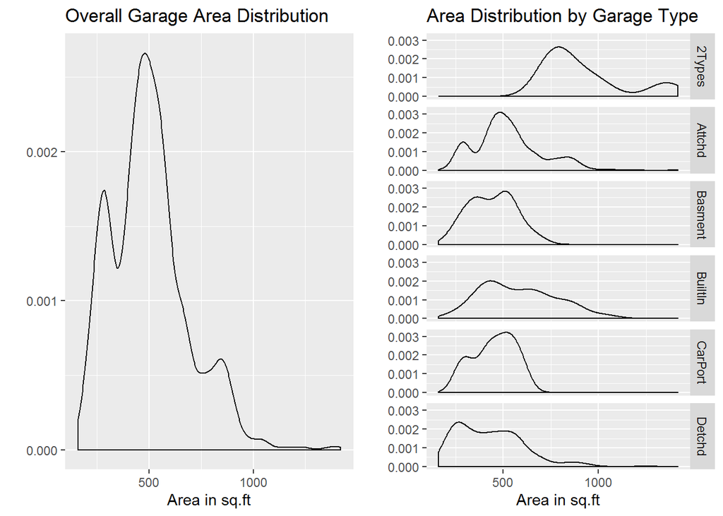

**Observations**

### Impute Missing Data

1. We impute
   1. the mode values for missing `MSZoning` and `Utilities` of appropriate `Neighborhood`
   2. the mode values for missing `Exterior1st`, `Exterior2nd`, `KitchenQual`, `Functional` and `SaleType` of appropriate `MSSubClass`, and
   3. the mode and median values respectively for missing `GarageCars` and `GarageArea` of appropriate `GarageType`
2. Example ids. 2121 and 2189 both report absence of a basement and hence we can impute `0` to all related features like `BsmtFinSF1`, `BsmtFinSF2`, `BsmtUnfSF`, `TotalBsmtSF`, `BsmtFullBath` and `BsmtHalfBath`.
3. Finally, we reconfirm that there are no more missing values.

```
## [1] "Features in test dataset reporting NA values"
```

```
## named integer(0)
```

### Saving a Baseline

1. We have “cleaned” both the *train* and *test* datasets.
2. We assign the `Id` as rownames for the examples and then drop the `Id` feature.
3. Finally, we separate the *train* and the *test* datasets and save then as *.Rda* files as baseline versions